# Statistical Test (Non-Parametric)

Bis335

## Contents

### Distribution-free method

- When the assumption of model cannot be satisfied: Sample size, Deviation
- Qualitative or Categorical data

### Goodness-Of-Fit Test for Categorical Data analysis (apprx. parametric)

- Fit to the expected value or model distribution
- One-factor classification test (Chi-square test):
- Multi-factor classification test (contingency or dependency test)

### Sign or order analysis

- Sign Test, Signed rank test
- Wilcoxon rank-sum test (two sample test: t-test alternative)
- Kruskal-Wallis test (multi-sample test: ANOVA F-test alternative)

### Extra issues (not included in this session)

- Randomness: Run test, Correlation: Spearman’s rank correlation test
- Evaluation of overall performance and errors including multiple testing error
- Analysis of heterogeneous source of data: integrative or meta analysis.

## Tutorial

### Example of chi-square test I (s7, Hayter p468)

Out of $n = 46$ machine breakdowns, $x_1 = 9$ are attributable to electrical problems, $x_2 = 24$ are attributable to mechanical problems, and $x_3 = 13$ are attributable to operator misuse. It is suggested that the probabilities of these three kinds of breakdown are respectively
$$p_1^* = 0.2, \ p_2^* = 0.5, \ p_3^*=0.3$$
Examine plausibility of this suggestion with a chi-square goodness of fit test.

Consider the null hypothesis $H_0 : p_1 = 0.2, p_2 = 0.5, p_3 = 0.3$

Under this null hypothesis the expected cell frequencies are

$e_1 = np_{1}^* = 46 \times 0.2 = 9.2$

$e_2 = np_{2}^*= 46 \times 0.5 = 23.0$

$e_3 = np_{3}^*= 46 \times 0.3 = 13.8$

Pearson chi-square statistic: $\chi^2 = \frac{(9.0 - 9.2)^2}{9.2} + \frac{(24.0 - 23.0)^2}{23.0} + \frac{(13.0 - 13.8)^2}{13.8} = 0.0942$

Likelihood ratio chi-square statistic: $G^2 = 2 \times \bigg(9.0 \times ln \bigg(\frac{9.0}{9.2}\bigg) + 24.0 \times \bigg(\frac{24.0}{23.0}\bigg) + 13.0 \times \bigg(\frac{13.0}{13.8}\bigg) \bigg) = 0.0945$

which, compared with a chi-square distribution with $k-1 = 3 - 1 = 2$ degrees of freedom (which is an exponential distribution with mean 2) give a p-value of
$$p-value \approxeq p(\chi_2^2 \geq 0.094) = 0.95$$

```r
x1 <- 9; x2 <- 24; x3 <- 13
p1 <- 0.2; p2 <- 0.5; p3 <- 0.3
df <- 2
n <- sum(x1, x2, x3)
e1 <- n * p1
e2 <- n * p2
e3 <- n * p3

chi_square <- ((x1 - e1)^2/e1) + ((x2 - e2)^2/e2) + ((x3 - e3)^2/e3); chi_square
```

```
## [1] 0.0942029
```

```r
G_square <- 2 * (x1 * log(x1/e1) + x2 * log(x2/e2) + x3 * log(x3/e3)); G_square
```

```
## [1] 0.09454107
```

```r
pchisq(chi_square, df, lower.tail = FALSE)
```

```
## [1] 0.9539906
```

```r
pexp(chi_square, rate = 1/2, lower.tail = FALSE) # exponential distribution with mean = 2
```

```
## [1] 0.9539906
```

```r
pchisq(G_square, df, lower.tail = FALSE)
```

```
## [1] 0.9538293
```

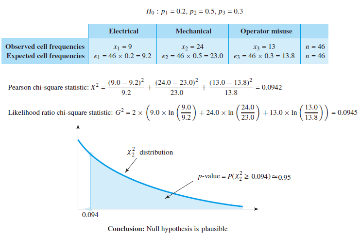

### Example of chi-square test II (s8)

The number of accidents per week during 50 weeks are collected. How can we test of size $\alpha = 0.05$ for the hypothesis that the accidents follows Poisson distribution model?

| y | Frequency |
| --- | --- |
| 0 | 32 |
| 1 | 12 |
| 2 | 6 |
| 3 or more | 0 |

$p(y|\lambda) = \frac{\lambda^y e^{-\lambda}}{y!}, \ \ \ \ \ \ \ y = 0, 1, 2, ...$

**Answer**

Goodness of fit test for $H_0$: expected value from Poisson distribution = observed values.

Expected values: $n_i = np_i$, need to know $\lambda$ for $p_i$, MLE of $\lambda: \hat \lambda = \bar Y: \frac{(12 \times 1 + 6 \times 2)}{50} = 0.48$

$p_1 = P(Y=0) = e^{-\lambda}, \ \ \hat p_1 = e^{-0.48} = 0.619$

$p_2 = P(Y=1) = \lambda e^{-\lambda}, \ \ \hat p_2 = 0.48 \times e^{-0.48} = 0.297$

$p_3 = P(Y \geq 2) = 1 - e^{-\lambda} - \lambda e^{-\lambda}, \ \ \hat p_3 = 1 - \hat p_2 - \hat p_3 = 0.084$

$\hat E(n_1) = n \hat p_1 = 50 \times 0.619 = 30.95$

$\hat E(n_2) = n \hat p_2 = 50 \times 0.297 = 14.85$

$\chi^2 = \sum_{i=1}^3 \frac{[n_i - \hat E(n_i)]^2}{\hat E(n_i)}$

$\chi^2 = \frac{(32-30.95)^2}{30.95} + \frac{(12-14.85)^2}{14.85} + \frac{(6-4.20)^2}{4.20}$

$\chi^2_{0.05} = 3.841$, with 1 df.

d.f. is 1 rather than 2 because one more variable is fixed by determining $\lambda$ mean of $Y_i = np_i$

```r
alpha <- 0.05
y <- c(0, 1, 2, 3)
freq <- c(32, 12, 6, 0)
n <- sum(freq)
lambda_hat <- sum(y*freq)/n

# assume Poisson distribution
p1 <- exp(-lambda_hat)
p2 <- lambda_hat * exp(-lambda_hat)
p3 <- 1 - p1 - p2 # 2 or more weeks
e1 <- n * p1; e2 <- n * p2; e3 <- n * p3
chi_square <- ((freq[1] - e1)^2/e1) + ((freq[2] - e2)^2/e2) + ((freq[3] - e3)^2/e3)

# df = 1, for p
qchisq(0.05, df = 1, lower.tail = FALSE)
```

```
## [1] 3.841459
```

```r
# pvalue
pchisq(chi_square, df = 1, lower.tail = FALSE)
```

```
## [1] 0.2462138
```

Since $\chi^2_{.05} = 3.841$ with df = 1, $P(\chi^2 > 1.354) = 0.245$, accept null Hypothesis with $\alpha$ = 0.05 because p-value > 0.05. Therfore, Poisson distribution can be used as a model of number of accidents/week.

### Test of Independence (s11, Hayter p483)

Three drugs are compared with respect to the types of allergic reaction that they cause to patients. A group of $n = 300$ patients is randomly split into three groups of 100 patients, each of which is given one of the three drugs. The patients are then categorized as being *hyperallergic, allergic, mildly allergic*, or as having *no allergy*.

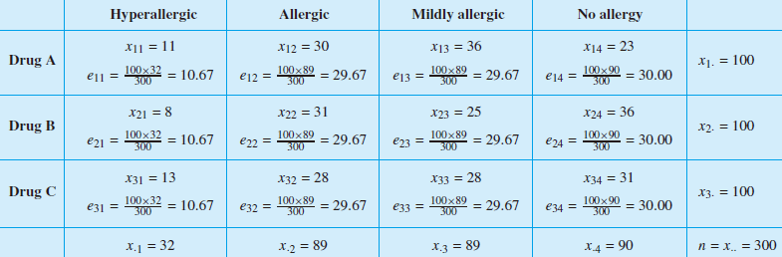

the contingency table looks like below.

|  | Hyperallergic | Allergic | Mildly allergic | No allergy |
| --- | --- | --- | --- | --- |
| Drug A | 11 | 30 | 36 | 23 |
| Drug B | 8 | 31 | 25 | 36 |
| Drug C | 13 | 28 | 28 | 31 |

Test for independence between the type of drug and the type of reaction.

```r
# Manual calculation - calculation of expected value

# data
data <- matrix(c(11, 30, 36, 23, 8, 31, 25, 36, 13, 28, 28, 31), nrow = 3, byrow = TRUE)
rownames(data) <- c("Drug A", "Drug B", "Drug C")
colnames(data) <- c("Hyperallergic", "Allergic", "Mildly allergic", "No allergy")

# contingency table
dt <- cbind(data, rowSums(data))
dt <- rbind(dt, colSums(dt))

# define result dataframe
expDat <- matrix(rep(0,12), nrow = 3)

# calculate expected counts
for (i in 1:4) {
expDat[,i] <- dt[1:3, 5]*dt[4,i]/dt[4,5]
}

# Print expected counts
expDat
```

```
##          [,1]     [,2]     [,3] [,4]
## [1,] 10.66667 29.66667 29.66667   30
## [2,] 10.66667 29.66667 29.66667   30
## [3,] 10.66667 29.66667 29.66667   30
```

```r
# calculate chisq statistic
chisq.res <- sum((data - expDat)^2/expDat); chisq.res
```

```
## [1] 6.391245
```

```r
# p-value
pchisq(chisq.res, df = 7 - 1, lower.tail = FALSE)
```

```
## [1] 0.3808181
```

```r
# using base R package
chisq <- chisq.test(data)
chisq
```

```
##
##  Pearson's Chi-squared test
##
## data:  data
## X-squared = 6.3912, df = 6, p-value = 0.3808
```

```r
chisq$expected
```

```
##        Hyperallergic Allergic Mildly allergic No allergy
## Drug A      10.66667 29.66667        29.66667         30
## Drug B      10.66667 29.66667        29.66667         30
## Drug C      10.66667 29.66667        29.66667         30
```

The null hypothesis of independence between the type of drug and the type of reaction can be interpreted as meaning that the chances of the various kinds of allergic reaction are the same for each of the three drugs. This means that there is a set of probability values $p_1, p_2, p_3$, and $p_4$ that represent the probabilities of getting the four types of reaction regardless of which drug is used. If the null hypothesis of independence is rejected, then this implies that there is evidence to conclude that the three drugs have different sets of probability values for the four types of reaction. This means that the three types of drug cannot be considered to be equivalent in terms of the reactions that they cause. (Actually, two of the three drugs could still be equivalent, but all three cannot be the same)

$p-value = 0.3808 > 0.05$, implies that the null hypothesis of independence is plausible, and so there is no evidence to conclude that the three drugs are any different with respect to the types of allergic reaction that they cause.

### Simpson’s Paradox (s12)

The paradox where a trend appeared in segmented groups of data disappears or reverses when these groups are combined. Using iris data set, we are going to investigate this topic as an example.

```r
library(dplyr)
```

```r
library(ggplot2)
# correlation for all species
cor(iris[-5])
```

```
##              Sepal.Length Sepal.Width Petal.Length Petal.Width
## Sepal.Length    1.0000000  -0.1175698    0.8717538   0.8179411
## Sepal.Width    -0.1175698   1.0000000   -0.4284401  -0.3661259
## Petal.Length    0.8717538  -0.4284401    1.0000000   0.9628654
## Petal.Width     0.8179411  -0.3661259    0.9628654   1.0000000
```

```r
# correlation for each species
species_all <- unique(iris$Species)
for (species in species_all) {
  df <- iris %>% filter(Species == species)
  message(species)
  print(cor(df[-5]))
}
```

```
## setosa
```

```
##              Sepal.Length Sepal.Width Petal.Length Petal.Width
## Sepal.Length    1.0000000   0.7425467    0.2671758   0.2780984
## Sepal.Width     0.7425467   1.0000000    0.1777000   0.2327520
## Petal.Length    0.2671758   0.1777000    1.0000000   0.3316300
## Petal.Width     0.2780984   0.2327520    0.3316300   1.0000000
```

```
## versicolor
```

```
##              Sepal.Length Sepal.Width Petal.Length Petal.Width
## Sepal.Length    1.0000000   0.5259107    0.7540490   0.5464611
## Sepal.Width     0.5259107   1.0000000    0.5605221   0.6639987
## Petal.Length    0.7540490   0.5605221    1.0000000   0.7866681
## Petal.Width     0.5464611   0.6639987    0.7866681   1.0000000
```

```
## virginica
```

```
##              Sepal.Length Sepal.Width Petal.Length Petal.Width
## Sepal.Length    1.0000000   0.4572278    0.8642247   0.2811077
## Sepal.Width     0.4572278   1.0000000    0.4010446   0.5377280
## Petal.Length    0.8642247   0.4010446    1.0000000   0.3221082
## Petal.Width     0.2811077   0.5377280    0.3221082   1.0000000
```

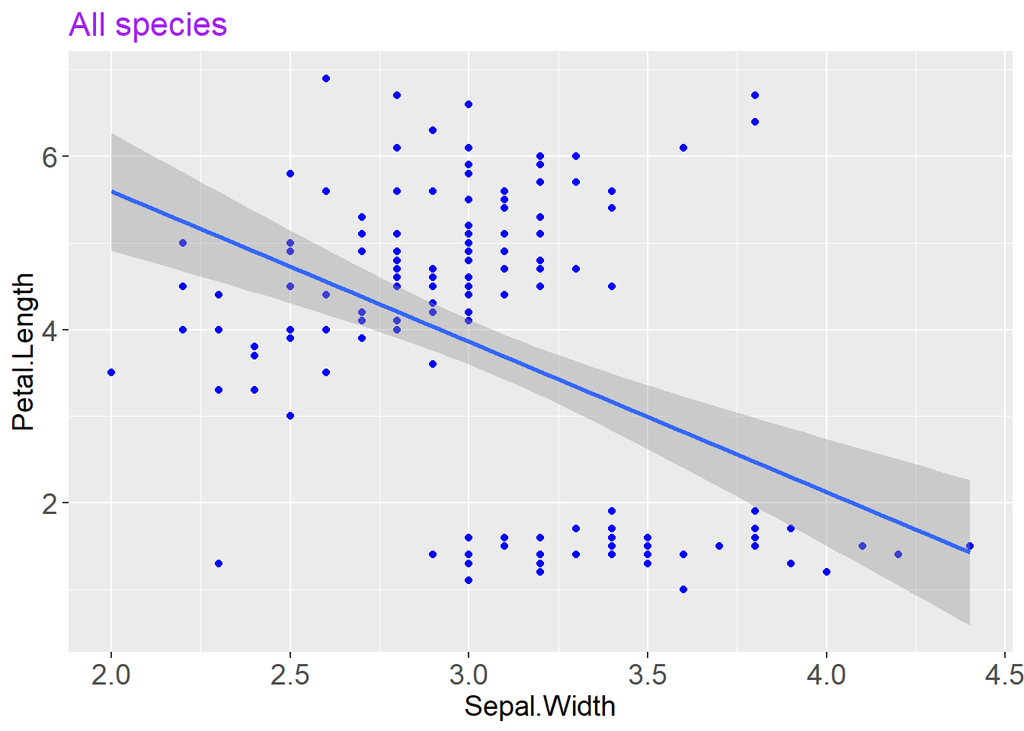

```r
# all species
iris %>% ggplot(aes(x = Sepal.Width , y = Petal.Length)) +
  geom_point(color = 'blue') +
  ggtitle('All species') +
  theme(axis.title = element_text(size = 14),
        plot.title = element_text(size = 16, colour = "purple"),
        axis.text = element_text(size = 14)) +
  geom_smooth(method = "lm")
```

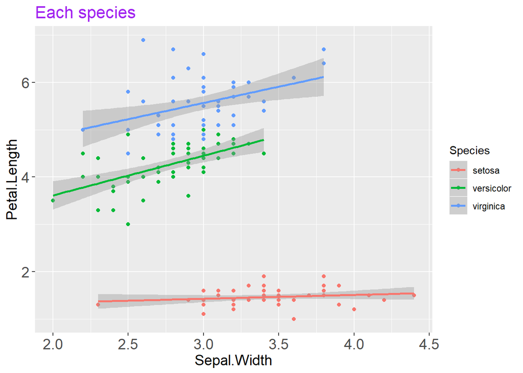

```r
# each species
iris %>%
  ggplot(aes(x = Sepal.Width , y = Petal.Length, color = Species)) +
  geom_point() +
  ggtitle('Each species') +
  geom_smooth(method = 'lm') +
  theme(axis.title = element_text(size = 14),
        plot.title = element_text(size = 16,colour = "purple"),
        axis.text = element_text(size = 14))
```

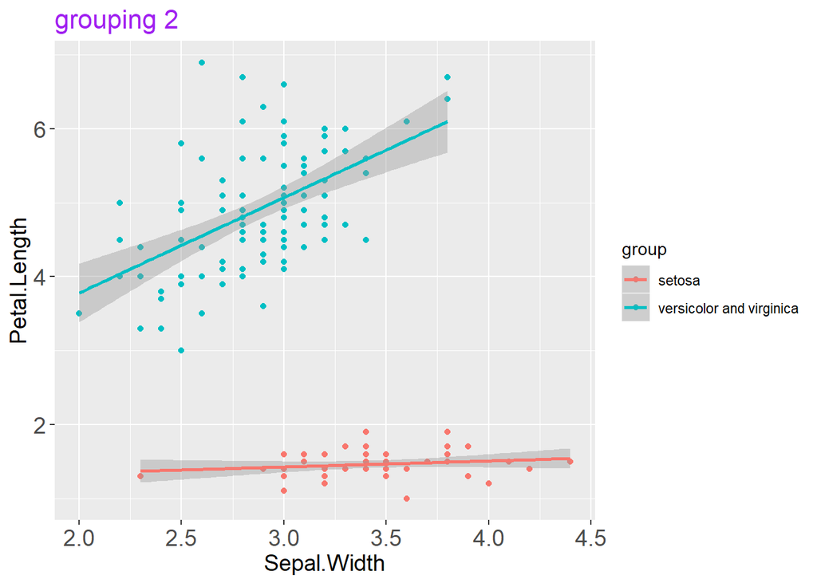

```r
# each species
iris %>%
  mutate(group = ifelse(Species %in% c("versicolor", 'virginica'),
                        'versicolor and virginica','setosa')) %>%
  ggplot(aes(x = Sepal.Width , y = Petal.Length, color = group)) +
  geom_point() +
  ggtitle('grouping 2') +
  theme(axis.title = element_text(size = 14),
        plot.title = element_text(size = 16,colour = "purple"),
        axis.text = element_text(size = 14)) +
  geom_smooth(method = "lm")
```

### Kolomogorov-smirnov Test (2 samples) (s15, Hayter 718)

In petroleum processing, changes in the conditions of crude oil and natural gas may cause dissolved waxes to crystallize and to therefore affect the operation of processing equipment. If the waxes can be made to crystallize in a structure that is less likely to form a deposit, or if the waxes can be prevented from crystallizing altogether, then a problem that may be of serious concern to the petroleum industry can be mitigated. It is therefore important to study the crystallization properties of the dissolved waxes.

An experiment is performed whereby a solution of waxes is expanded rapidly through a nozzle, as shown in Figure below, so that the wax particles can be collected on a plate. Scanning electron microscopy is then used to photograph the samples of wax particles so that their diameters can be measured. A question of importance is how the pre-expansion temperature of the solution affects the particle sizes.

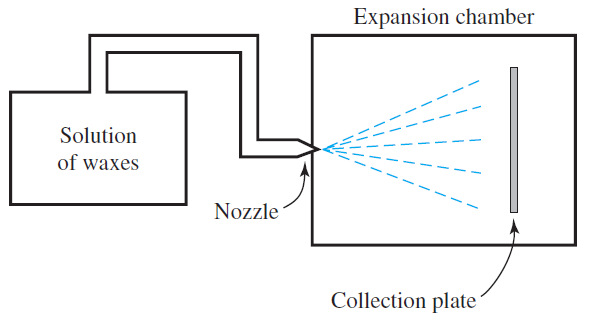

In the first experiment a pre-expansion temperature of $80^\circ C$ is used, and in a second experiment a pre-expansion temperature of $170^\circ C$ is used. In either case 36 samples of particles are obtained, and the means of the particle diameters within each sample are calculated as shown below.

```
## [1] "Pre-expansion temperature of 80"
```

| 9.00 | 9.50 | 9.75 | 10.50 | 10.50 | 11.50 | 12.00 | 12.25 | 12.75 |
| --- | --- | --- | --- | --- | --- | --- | --- | --- |
| 13.25 | 14.25 | 14.75 | 15.25 | 17.00 | 18.25 | 18.25 | 18.50 | 18.75 |
| 19.25 | 19.75 | 20.25 | 20.75 | 22.00 | 22.75 | 22.75 | 23.00 | 23.00 |
| 23.25 | 26.00 | 26.00 | 29.00 | 31.75 | 32.50 | 33.00 | 36.50 | 38.00 |

| n | mean | sd | max | upper | median | lower | min |
| --- | --- | --- | --- | --- | --- | --- | --- |
| 36 | 19.875 | 7.881828 | 38 | 23.0625 | 19 | 13.125 | 9 |

```
## [1] "Pre-expansion temperature of 170"
```

| 4.00 | 4.17 | 4.75 | 4.83 | 5.17 | 5.33 | 5.50 | 5.67 | 5.67 |
| --- | --- | --- | --- | --- | --- | --- | --- | --- |
| 5.67 | 6.17 | 6.17 | 6.67 | 6.67 | 7.33 | 7.60 | 7.67 | 7.67 |
| 7.75 | 8.17 | 8.50 | 8.50 | 8.67 | 8.67 | 8.67 | 9.17 | 9.17 |
| 9.33 | 9.44 | 9.67 | 10.00 | 10.00 | 10.25 | 10.67 | 10.83 | 12.16 |

| n | mean | sd | max | upper | median | lower | min |
| --- | --- | --- | --- | --- | --- | --- | --- |
| 36 | 7.675833 | 2.091119 | 12.16 | 9.21 | 7.71 | 5.67 | 4 |

How does the pre-expansion temperature affect the particle sizes?

We can test the effect of pre-expansion temperature with Kolomogorov-Smirnov statistic.

Formally, the value of the Kolomogorov-Smirnov statistic is

$$M = \frac{30}{36} = 0.8333$$

This value is the maximum vertical distance between the two empirical cumulative distribution functions $\hat F_A(x)$ and $\hat F_B(x)$, which occurs when $10.25 < x < 10.50$, in which case

$$\hat F_A(x) = \frac {3}{36} = 0.0833, \ \hat F_B(x) = \frac{33}{36} = 0.9167, \ and \ \ M = 0.8333$$

and also when $10.83 < x < 11.50$, in which case

$$\hat F_A(x) = \frac {5}{36} = 0.1389, \ \hat F_B(x) = \frac{35}{36} = 0.9722, \ and \ M = 0.8333$$

A size $\alpha = 0.01$ critical point is

$$d_{0.01}\sqrt{\frac{1}{n} + \frac{1}{m}} = 1.63 \times \sqrt{\frac{1}{36} + \frac{1}{36}} = 0.38$$

The value $M = 0.83$ is much larger than this critical point, which indicates that there is very strong evidence that the distributions of the particle sizez are different at the two different pre-expansion temperatures.

In general, to test difference of two samples (A, B) with their maximum distance of empirical cumulative function, with null hypothesis

$$H_0: F_{A}(x) = F_{B}(x)$$

use test statistic M: most different $F(x)_s$ as

$$M = max|\hat{F}_{A}(x) - \hat{F}_{B}(x)|$$

where $\hat{F}_{A}(x) = \frac{\#x_{i} \leq X}{n}$, $\hat{F}_{B}(x) = \frac{\#y_{i} \leq X}{n}$

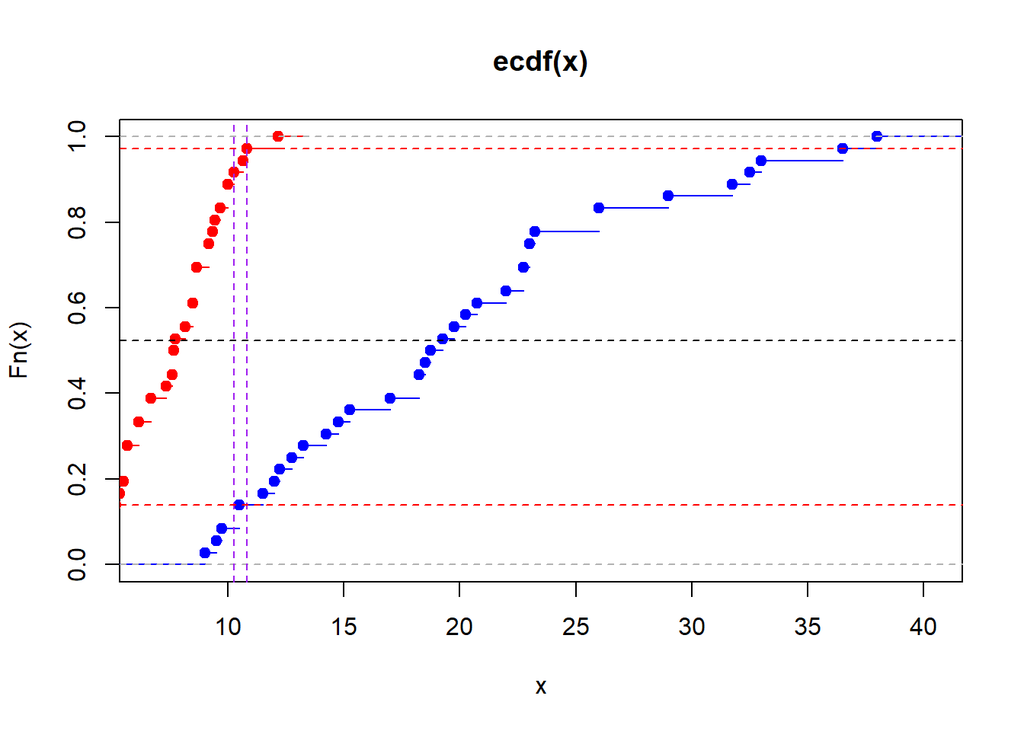

```r
A <- c(9, 9.5, 9.75, 10.5, 10.5, 11.5, 12, 12.25, 12.75,
         13.25, 14.25, 14.75, 15.25, 17, 18.25, 18.25, 18.5, 18.75,
         19.25, 19.75, 20.25, 20.75, 22, 22.75, 22.75, 23, 23,
         23.25, 26, 26, 29, 31.75, 32.5, 33, 36.5, 38)
B <- c(4, 4.17, 4.75, 4.83, 5.17, 5.33, 5.5, 5.67, 5.67,
       5.67, 6.17, 6.17, 6.67, 6.67, 7.33, 7.6, 7.67, 7.67,
       7.75, 8.17, 8.5, 8.5, 8.67, 8.67, 8.67, 9.17, 9.17,
       9.33, 9.44, 9.67, 10, 10, 10.25, 10.67, 10.83, 12.16)

da <- 1.63 # from Hayter p699 (for n > 40, a = 0.01)
cv <- 1.63 * sqrt(1/length(A) + 1/length(B))

plot.ecdf(A, col = "blue")
plot.ecdf(B, add = TRUE, col = "red")
abline(v = mean(10.25, 10.5), col = "purple", lty = 2)
abline(v = mean(10.83, 11.5), col = "purple", lty = 2)
abline(h = ecdf(A)(10.5) + cv, col = "black", lty = 2) # critical value
abline(h = ecdf(A)(10.5), col = "red", lty = 2) # M
abline(h = ecdf(B)(11.5), col = "red", lty = 2)
```

```r
# using base R
ks.test(A, B)
```

```
##
##  Two-sample Kolmogorov-Smirnov test
##
## data:  A and B
## D = 0.83333, p-value = 2.778e-11
## alternative hypothesis: two-sided
```

### Sign Test (Matched Pair Samples Median) (s17, Wackerly p744)

**A general two-sample shift model**

Many times, an experimenter takes observations from two populations with the objective of testing whether the populations have the same distribution. For example, if independent random samples $X_1, X_2, ..., X_{n_1}$ and $Y_1, Y_2, ..., Y_{n_2}$ are taken from normal populations with equal variances and respective means $\mu_X$ and $\mu_Y$, the experimenter may wish to test $H_0: \mu_X - \mu_Y = 0$ versus $H_a: \mu_X - \mu_Y \neq 0$. In this case, if $H_0$ is true, both populations are normally distributed with the same mean and the same variance; that is, the population distributions are identical. If $H_a$ is true, then $\mu_X \neq \mu_Y$ and the distributions of $X_1$ and $Y_1$ are the same, except that the location parameter ($\mu_Y$) for $Y_1$ is differ from the location parameter ($\mu_X$) for $X_1$. Hence, the distribution of $Y_1$ is shifted to the right or left of the distribution of $X_1$

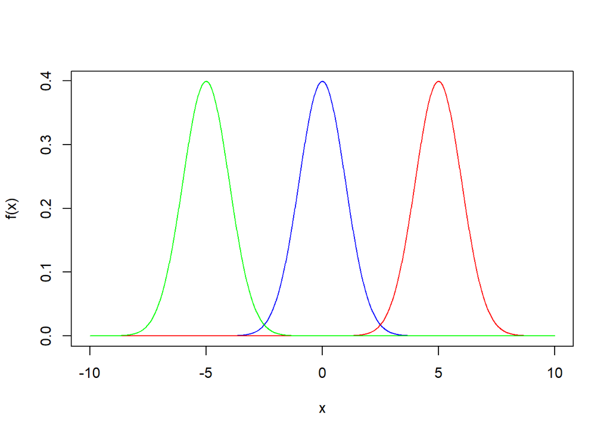

```r
mu <- 0; sd <- 1; theta <- 5
mu_y1 <- 0 + theta
mu_y2 <- 0 - theta

range <- seq(-10, 10, 0.01)
x1 <- dnorm(range, mu, sd)
y1 <- dnorm(range, mu_y1, sd)
y2 <- dnorm(range, mu_y2, sd)

plot(range, x1, type = 'l', col = "blue", ylab = "f(x)", xlab = "x")
lines(range, y1, col = "red")
lines(range, y2, col = "green")
```

This is an example of a two-sample parametric *shift (or location) model*. The model is parametric because the distributions are specified (normal) except for the values of the parameters $\mu_X, \mu_Y$, and $\sigma^2$. The amount that the distribution of $Y_1$ is shifted to the right or left ofthe distribuiton of $X_1$ is $\mu_Y - \mu_X$.

Now, Let $X_1, X_2, ..., X_{n_1}$ be a random sample from a population with distribution function $F(x)$ and let $Y_1, Y_2, ..., Y_{n_2}$ be a random sample from a populatio with distribution function G(y). If we wish to test whether the two populations have the same distribution - that is, $H_0: F(z) = G(z)$ versus $H_a: F(z) \neq G(z)$, with the actual form of $F(z)$ and $G(z)$ unspecified - a non parametric method is required.

Notice that $H_a$ is a very broad hypothesis. Many times, an experimenter may wish to consider the more specific alternative hypothesis that $Y_1$ has the same distribution as $X_1$ shifted by an (unknown) amount $\theta$ - that is, that the distributions *differ in location*. Then $G(y) = P(Y_1 \leq y) = P(X_1 \leq y-\theta) = F(y-\theta)$ for some unknown parameter value $\theta$. Notice that the particular form of $F(x)$ remains unspecified.

In summary, we refer to the two-sample shift (location) model as we assume that $X_1, X_2, ..., X_{n_1}$ constitute a random sample from distribution fuction $F(x)$ and that $Y_1, Y_2, ..., Y_{n_2}$ constitute a random sample from distribution function $G(y) = F(y-\theta)$ for some unknown value $\theta$. for the two-sample shift model, $H_0:F(z) = G(z)$ is equivalent to $H_0: \theta =0$. If $\theta$ is greater (less) than 0, then the distribution of Y-values is locatd to the right (left) of the distribution of the X-values.

**The Sign test for a matched-pairs experiment**

Suppose that we have n pairs of observations of the form $(X_i , Y_i)$ and that we wish to test the hypothesis that the distribution of the $X$’s is the same as that of the $Y$’s versus the alternative that the distributions differ **in location**. We let $D_i = X_i - Y_i$. One of the simplest nonparametric tests is based on the signs of these differences and, reasonably enough, is called the *sign test*. Under the null hypothesis that $X_i$ and $Y_i$ come from the same continuous probability distributions, the probability that $D_i$ is positive is equal to $\frac{1}{2}$ (as is the probability that $D_i$ is negative). Let $S$ denote the total number of positive (or negative) differences. Then if the variables $X_i$ and $Y_i$ have the same distribution, $S$ has a binomial distribution with $p = \frac{1}{2}$, and the rejection region for a test based on $S$ can be obtained by using the binomial probability distribution.

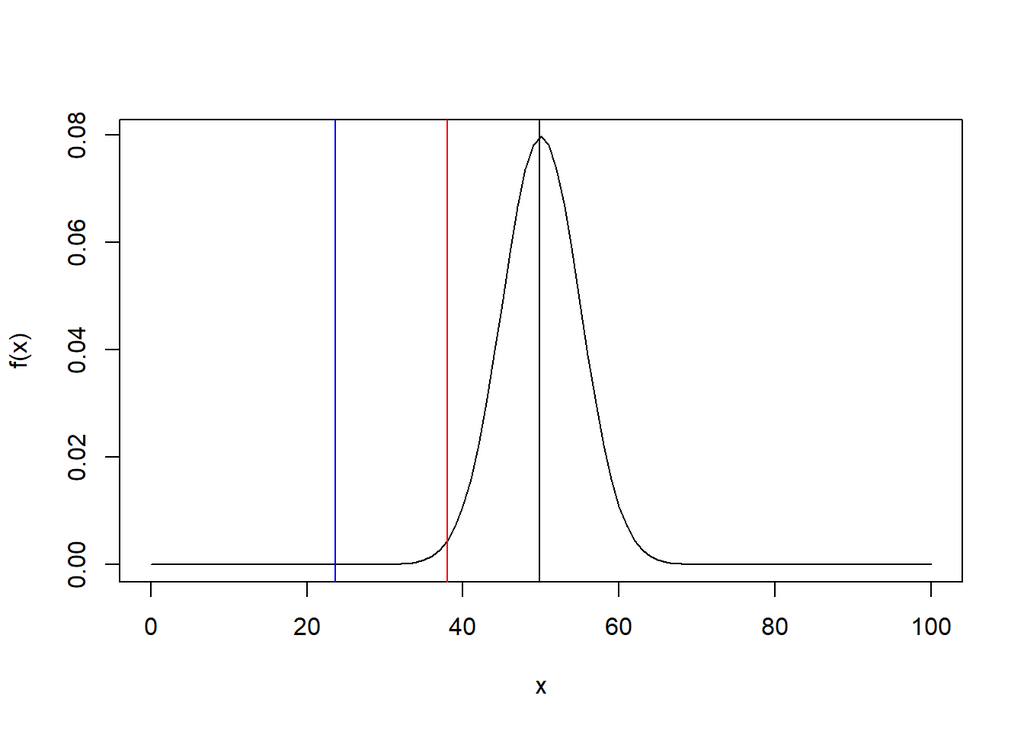

```r
mu_x <- 0; sd <- 1; theta <- 1; n <- 100
mu_y <- 0 + theta
S_equal <- S_nonequal <- vector(length = n)

# sample S n times
for (i in 1:n) {
  x1 <- rnorm(n, mu, sd)
  x2 <- rnorm(n, mu, sd)
  y1 <- rnorm(n, mu_y, sd)
  S_equal[i] <- sum(x1 - x2 > 0) # D = x1 - x2
  S_nonequal[i] <- sum(x1 - y1 > 0) # D = x1 - y1
}

# estimate mu of S
mu_S_equal <- mean(S_equal)
mu_S_nonequal <- mean(S_nonequal)

# plot S on the binomial distribution with probaility = 1/2
plot(0:n, dbinom(0:n, size = n, prob = 0.5), type = 'l', ylab = "f(x)", xlab = "x")
abline(v = mu_S_equal)
abline(v = mu_S_nonequal, col = "blue")
abline(v = qbinom(0.01, n, prob = 0.5), col = "red") # critical value a = 0.05
```

```r
# pvalue
pbinom(mu_S_equal, n, prob = 0.5) # drawn from the same distribution
```

```
## [1] 0.4602054
```

```r
pbinom(mu_S_nonequal, n, prob = 0.5) # drawn from the same distribution with different location parameter (mu)
```

```
## [1] 2.75679e-08
```

```r
# cf) z approximation, see later part of this tutorial
z1 <- (2 * mu_S_equal - n) / sqrt(n)
z2 <- (2 * mu_S_nonequal - n) / sqrt(n)

pnorm(z1)
```

```
## [1] 0.4832493
```

```r
pnorm(z2)
```

```
## [1] 6.821188e-08
```

```r
qnorm(0.01) # critical value
```

```
## [1] -2.326348
```

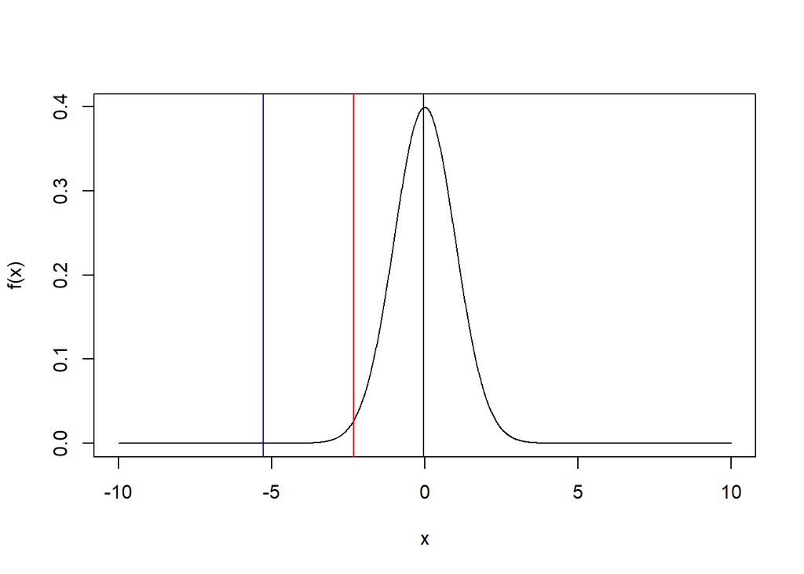

```r
# plot S on the normal distribution with mu_x and sd
plot(seq(-10,10,0.01), dnorm(seq(-10,10,0.01), mu_x, sd), type = 'l', ylab = "f(x)", xlab = "x")
abline(v = z1)
abline(v = z2, col = "blue")
abline(v = qnorm(0.01, mu_x, sd), col = "red") # critical value a = 0.05
```

The sign test is summarized as follows.

Let $p = P(X > Y)$.

Null hypothesis: $H_0: p = \frac{1}{2}$ or $H_0: median \ of \ D_i = 0$

Alternative hypothesis: $H_a: p > \frac{1}{2} or \ (p < \frac{1}{2} \ or \ p \neq \frac{1}{2})$ or $H_a: median \ of \ D_i \neq 0$

Test statistic: $S = \ number \ of \ positive \ differences \ where \ D_i = X_i - Y_i$

Rejection region:

- For $H_a: p > \frac{1}{2}$, reject $H_0$ for the largest values of S
- For $H_a: p < \frac{1}{2}$, reject $H_0$ for the smallest values of S
- For $H_a: p \neq \frac{1}{2}$, reject $H_0$ for very large or very small values of S

Asummptions: The pairs $(X_i, Y_i)$ are randomly and independently selected

**Example**

The number of defective electrical fuses produced by each of two production lines, $A$ and $B$,was recorded daily for a period of 10 days, with the results shown in Table below.

| Day | A | B |
| --- | --- | --- |
| 1 | 172 | 201 |
| 2 | 165 | 179 |
| 3 | 206 | 159 |
| 4 | 184 | 192 |
| 5 | 174 | 177 |
| 6 | 142 | 170 |
| 7 | 190 | 182 |
| 8 | 169 | 179 |
| 9 | 161 | 169 |
| 10 | 200 | 210 |

Assume that both production lines produced the same daily output. Compare the number of defectives produced by $A$ and $B$ each day and let $S$ equal the number of days when $A$ exceeded $B$. Do the data present sufficient evidence to indicate that either production line produces more defectives than the other? State the null hypothesis to be tested and use $S$ as a test statistic.

**Solution** $H_0:$ The two distributions of defectives are identical

Formally, when $d_i = x_i - y_i, \ for \ i = 1,...,n$ and $d_i$ are assumed to be i.i.d., values of $x_i$ and $y_i$ are ordered.

$H_0: F(d_0) = p_0 \ (d_0 = 0, p_0 = 0.5, \ actually \ means \ F_0 = P(\#d_i > d_0) = P(\#x_i > \#y_i) = 0.5)$

Test statistic: $S = \# of \ d_i > d_0 \ or \ x_i > y_i$: does not count those $x_i = y_i$

Rejection region: some extreme values of $S \geq S_0$ or $S \leq S_0$, p-value of $S < \alpha$ (Iterative test of p value from the extreme values to the smaller values) If there are ties (no difference), we don’t use them in the calculation (sample size $n$ is reduced too)

let $S$ be the number of days that the observed number of defectives for production line A exceeds that for line B. from the data, $S = 2$. The p-value is given as $2 \times P(S \leq 2)$ (two-sided test). Under the null hypothesis, $S$ has a binomal distribution with $n = 10, p = 0.5$, so that p-value is given as
$$p-value = 2 P(S \leq 2) = 2 \times \sum_{x=0}^2 {10 \choose{x}} 0.5^{10} = 0.11$$
Therefore, 0.11 is the smallest value of $\alpha$ for which the null hypothesis can be rejected.

```r
# the test result of A and B
Day <- 1:10
A <- c(172, 165, 206, 184, 174, 142, 190, 169, 161, 200)
B <- c(201, 179, 159, 192, 177, 170, 182, 179, 169, 210)
diff <- A - B
S <- sum(diff > 0); S
```

```
## [1] 2
```

```r
# Direct calculation of rejection region (calculation of pvalue)
RR1 <- choose(10,0) * 0.5^10 + choose(10,10) * 0.5^10 # S = 0

RR2 <- choose(10,0) * 0.5^10 + choose(10,1) * 0.5^10 + # S = 1
       choose(10,9) * 0.5^10 + choose(10,10) * 0.5^10

RR3 <- choose(10,0) * 0.5^10 + choose(10,1) * 0.5^10 + choose(10,2) * 0.5^10 +  # S = 2
       choose(10,8) * 0.5^10 + choose(10,9) * 0.5^10 + choose(10,10) * 0.5^10

RR1; RR2; RR3
```

```
## [1] 0.001953125
```

```
## [1] 0.02148438
```

```
## [1] 0.109375
```

```r
# Using binomial distribution (calculation of pvalue)
2 * pbinom(2, size = length(A - B), prob = 0.5)
```

```
## [1] 0.109375
```

```r
# R package
library(BSDA)
SIGN.test(A,B)
```

```
##
##  Dependent-samples Sign-Test
##
## data:  A and B
## S = 2, p-value = 0.1094
## alternative hypothesis: true median difference is not equal to 0
## 95 percent confidence interval:
##  -23.457778   4.431111
## sample estimates:
## median of x-y
##            -9
##
## Achieved and Interpolated Confidence Intervals:
##
##                   Conf.Level   L.E.pt  U.E.pt
## Lower Achieved CI     0.8906 -14.0000 -3.0000
## Interpolated CI       0.9500 -23.4578  4.4311
## Upper Achieved CI     0.9785 -28.0000  8.0000
```

One problem that may arise in connection with a sign test is that the observations associated with one or more pairs may be equal and therefore may result in ties. When this situation occurs, delete the tied pairs and reduce $n$, the total number of pairs. You will also encounter situations where $n$, the number of pairs, is large. Then, the values of $\alpha$ associated with the sign test can be approximated by using the normal approximation to the binomial probability distribution. You can verify (by comparing exact probabilities with their approximations) that these approximations will be quite adequate for $n$ as small as 10 or 15. This result is due to the symmetry of the binomial probability distribution for $p = 0.5$. For $n \geq 25$, the $Z$ test will suffice, where
$$Z = \frac{S - np}{\sqrt {npq}} = \frac{S - \frac{n}{2}}{\frac{1}{2}\sqrt n} = \frac{2S-n}{\sqrt n}$$

```r
Day <- 1:10
A <- c(172, 165, 206, 184, 174, 142, 190, 169, 161, 200)
B <- c(201, 179, 159, 192, 177, 170, 182, 179, 169, 210)
diff <- A - B
S <- sum(diff > 0); S
```

```
## [1] 2
```

```r
z <- (2 * S - length(diff)) / sqrt(length(diff))
pnorm(z) # inexact approximation because of too small n
```

```
## [1] 0.02888979
```